# soilmoisture

**Made By DAHOU RENAUD L. Data Scientist in Benin**

- Whatsapp: +22967927952
- Email: dahou.r@yahoo.com

[figure not shown]

# A propos de la base de données

# Ensemble de données de référence hyperspectrale sur l'humidité du sol

Données d'échantillonnage hyperspectral et d'humidité du sol provenant d'une campagne sur le terrain. Karlsruhe (Allemagne), 2017.

**Présentation:** Felix M. Riese et Sina Keller, «Introducing a Self-Organizing Maps Framework for Soil Moisture Regression with Hyperspectral Data», dans *2018 IEEE International Geoscience and Remote Sensing Symposium (IGARSS)* , Valence , Espagne, 2018, accepté.

**Licence:** [GNU GPLv2] (https://www.gnu.org/licenses/gpl-2.0.html)

**Auteurs:**

- [Felix M. Riese, M.Sc.] (Mailto: felix.riese@kit.edu)
- [Dr. rer.nat. Sina Keller] (mailto: sina.keller@kit.edu)

## Description

Cet ensemble de données a été mesuré lors d'une campagne de terrain de cinq jours en mai 2017 à Karlsruhe, en Allemagne. Un échantillon de sol non perturbé est la pièce maîtresse de la configuration de mesure. L'échantillon de sol était constitué de sol nu sans aucune végétation et a été prélevé dans la région près de Waldbronn, en Allemagne.

Les capteurs suivants ont été déployés:

- Caméra instantanée Cubert UHD 285 **hyperspectrale** enregistrant 50 par 50 images avec 125 bandes spectrales allant de 450 nm à 950 nm et une résolution spectrale de 4 nm.
- Capteur de réflectométrie temporelle (TDR) TRIME-PICO à une profondeur de 2 cm mesurant **l'humidité du sol** en pourcentage.

## Variables

- **datetime:** date et heure de mesure
- **sol_humidité:** humidité du sol en%
- **température_sol:** température du sol en ° C
- **454, 458,… 946, 950:** bandes hyperspectrales en nm

## Connexion à notre répertoire

```python
from google.colab import drive
drive.mount('/content/drive/')
```

```python
import os
os.chdir("/content/drive/My Drive/DATASCIENCE/Projet/hyperspectral-soilmoisture")
```

```python
!jupyter nbconvert --to html soilmoisture.ipynb
```

### importation du jeu de donnée

```python
import pandas as pd

df= pd.read_csv('soilmoisture_dataset.csv')
df.head()
```

|  | index | datetime | soil_moisture | soil_temperature | 454 | 458 | 462 | 466 | 470 | 474 | 478 | 482 | 486 | 490 | 494 | 498 | 502 | 506 | 510 | 514 | 518 | 522 | 526 | 530 | 534 | 538 | 542 | 546 | 550 | … |
| --- | --- | --- | --- | --- | --- | --- | --- | --- | --- | --- | --- | --- | --- | --- | --- | --- | --- | --- | --- | --- | --- | --- | --- | --- | --- | --- | --- | --- | --- | --- |
| 0 | 0 | 2017-05-23 14:06:17 | 33.51 | 34.8 | 0.082131 | 0.055863 | 0.050047 | 0.047925 | 0.047498 | 0.046464 | 0.046669 | 0.046834 | 0.047469 | 0.048608 | 0.049343 | 0.050321 | 0.051308 | 0.053237 | 0.054277 | 0.055914 | 0.057526 | 0.059340 | 0.060957 | 0.062543 | 0.064105 | 0.066158 | 0.067752 | 0.069538 | 0.071269 | … |
| 1 | 1 | 2017-05-23 14:08:17 | 33.49 | 35.2 | 0.079510 | 0.055326 | 0.049116 | 0.047579 | 0.046745 | 0.046833 | 0.046329 | 0.047021 | 0.047660 | 0.048272 | 0.049086 | 0.050255 | 0.051465 | 0.052758 | 0.054272 | 0.055413 | 0.057245 | 0.058795 | 0.060666 | 0.062129 | 0.063881 | 0.065639 | 0.067651 | 0.069088 | 0.070921 | … |
| 2 | 2 | 2017-05-23 14:10:17 | 33.46 | 35.4 | 0.080599 | 0.054065 | 0.049150 | 0.047537 | 0.046525 | 0.046032 | 0.046276 | 0.046886 | 0.047230 | 0.048611 | 0.049242 | 0.049904 | 0.051134 | 0.052349 | 0.053945 | 0.055273 | 0.057153 | 0.059028 | 0.060561 | 0.061880 | 0.063493 | 0.066001 | 0.067201 | 0.069135 | 0.071210 | … |
| 3 | 3 | 2017-05-23 14:12:17 | 33.33 | 35.0 | 0.078024 | 0.054972 | 0.049052 | 0.047920 | 0.046883 | 0.046775 | 0.046835 | 0.046996 | 0.047565 | 0.048465 | 0.048690 | 0.049916 | 0.051437 | 0.052027 | 0.054373 | 0.056050 | 0.057311 | 0.058920 | 0.060888 | 0.062372 | 0.064291 | 0.065244 | 0.067219 | 0.068842 | 0.070901 | … |
| 4 | 4 | 2017-05-23 14:14:17 | 33.32 | 35.3 | 0.079973 | 0.055335 | 0.049314 | 0.047373 | 0.047028 | 0.046963 | 0.046763 | 0.047051 | 0.048083 | 0.048178 | 0.048974 | 0.050070 | 0.051606 | 0.053044 | 0.054380 | 0.055813 | 0.057545 | 0.059343 | 0.061065 | 0.062529 | 0.064171 | 0.065473 | 0.067356 | 0.069320 | 0.071357 | … |

5 rows × 129 columns

```python
df.shape
```

```
(679, 129)
```

```python
df.columns
```

```
Index(['index', 'datetime', 'soil_moisture', 'soil_temperature', '454', '458',
       '462', '466', '470', '474',
       ...
       '914', '918', '922', '926', '930', '934', '938', '942', '946', '950'],
      dtype='object', length=129)
```

Notre jeu de données comporte 679 lignes et 129 colonnes

### Vérifions s'il y a des données manquantes

```python
df.isnull().sum()
```

```
index               0
datetime            0
soil_moisture       0
soil_temperature    0
454                 0
                   ..
934                 0
938                 0
942                 0
946                 0
950                 0
Length: 129, dtype: int64
```

Nous n'avons aucune donnée manquante dans notre jeu.

# Vérifions si nous avons des données hors norme (outliers) avec une fonction mathématique Z-Score

```python
# dans un premier temps transformons la fonctionnalité datetime en série temporelle et  en index on n'aura pas à y verifiers des outliers
pd.to_datetime(df.datetime)
print(type(df.datetime))
df = df.set_index(['datetime'])
data_out=df.iloc[:,1:]
data_out.head()
```

```
<class 'pandas.core.series.Series'>
```

| datetime | soil_moisture | soil_temperature | 454 | 458 | 462 | 466 | 470 | 474 | 478 | 482 | 486 | 490 | 494 | 498 | 502 | 506 | 510 | 514 | 518 | 522 | 526 | 530 | 534 | 538 | 542 | 546 | 550 | 554 | 558 | … |
| --- | --- | --- | --- | --- | --- | --- | --- | --- | --- | --- | --- | --- | --- | --- | --- | --- | --- | --- | --- | --- | --- | --- | --- | --- | --- | --- | --- | --- | --- | --- |
| 2017-05-23 14:06:17 | 33.51 | 34.8 | 0.082131 | 0.055863 | 0.050047 | 0.047925 | 0.047498 | 0.046464 | 0.046669 | 0.046834 | 0.047469 | 0.048608 | 0.049343 | 0.050321 | 0.051308 | 0.053237 | 0.054277 | 0.055914 | 0.057526 | 0.059340 | 0.060957 | 0.062543 | 0.064105 | 0.066158 | 0.067752 | 0.069538 | 0.071269 | 0.072890 | 0.075050 | … |
| 2017-05-23 14:08:17 | 33.49 | 35.2 | 0.079510 | 0.055326 | 0.049116 | 0.047579 | 0.046745 | 0.046833 | 0.046329 | 0.047021 | 0.047660 | 0.048272 | 0.049086 | 0.050255 | 0.051465 | 0.052758 | 0.054272 | 0.055413 | 0.057245 | 0.058795 | 0.060666 | 0.062129 | 0.063881 | 0.065639 | 0.067651 | 0.069088 | 0.070921 | 0.072938 | 0.074584 | … |
| 2017-05-23 14:10:17 | 33.46 | 35.4 | 0.080599 | 0.054065 | 0.049150 | 0.047537 | 0.046525 | 0.046032 | 0.046276 | 0.046886 | 0.047230 | 0.048611 | 0.049242 | 0.049904 | 0.051134 | 0.052349 | 0.053945 | 0.055273 | 0.057153 | 0.059028 | 0.060561 | 0.061880 | 0.063493 | 0.066001 | 0.067201 | 0.069135 | 0.071210 | 0.072657 | 0.074421 | … |
| 2017-05-23 14:12:17 | 33.33 | 35.0 | 0.078024 | 0.054972 | 0.049052 | 0.047920 | 0.046883 | 0.046775 | 0.046835 | 0.046996 | 0.047565 | 0.048465 | 0.048690 | 0.049916 | 0.051437 | 0.052027 | 0.054373 | 0.056050 | 0.057311 | 0.058920 | 0.060888 | 0.062372 | 0.064291 | 0.065244 | 0.067219 | 0.068842 | 0.070901 | 0.073285 | 0.074840 | … |
| 2017-05-23 14:14:17 | 33.32 | 35.3 | 0.079973 | 0.055335 | 0.049314 | 0.047373 | 0.047028 | 0.046963 | 0.046763 | 0.047051 | 0.048083 | 0.048178 | 0.048974 | 0.050070 | 0.051606 | 0.053044 | 0.054380 | 0.055813 | 0.057545 | 0.059343 | 0.061065 | 0.062529 | 0.064171 | 0.065473 | 0.067356 | 0.069320 | 0.071357 | 0.073242 | 0.074871 | … |

5 rows × 127 columns

```python
#application de z-score
from scipy import stats
import numpy as np
z = np.abs(stats.zscore(data_out))
print(z)
```

```
[[0.53303342 0.57940338 0.82078974 ... 0.8524987  0.86466844 0.84175267]
 [0.52754294 0.49351431 0.91331845 ... 0.8199994  0.7945751  0.7706203 ]
 [0.51930722 0.45056977 0.87488836 ... 0.81993353 0.82869656 0.82761659]
 ...
 [0.49094108 0.42979322 0.34368139 ... 0.57983756 0.56660483 0.55465699]
 [0.4579982  0.42979322 0.36582915 ... 0.54232768 0.53430012 0.54385335]
 [0.4991768  0.47273775 0.27171107 ... 0.53797784 0.53425728 0.53578607]]
```

```python
threshold = 3
print(np.where(z > 3))
```

```
(array([530, 530, 531, ..., 558, 558, 559]), array([17, 20, 20, ..., 41, 42,  0]))
```

```python
data_in = data_out[(z <3).all (axis = 1)]
data_in.head()
```

| datetime | soil_moisture | soil_temperature | 454 | 458 | 462 | 466 | 470 | 474 | 478 | 482 | 486 | 490 | 494 | 498 | 502 | 506 | 510 | 514 | 518 | 522 | 526 | 530 | 534 | 538 | 542 | 546 | 550 | 554 | 558 | … |
| --- | --- | --- | --- | --- | --- | --- | --- | --- | --- | --- | --- | --- | --- | --- | --- | --- | --- | --- | --- | --- | --- | --- | --- | --- | --- | --- | --- | --- | --- | --- |
| 2017-05-23 14:06:17 | 33.51 | 34.8 | 0.082131 | 0.055863 | 0.050047 | 0.047925 | 0.047498 | 0.046464 | 0.046669 | 0.046834 | 0.047469 | 0.048608 | 0.049343 | 0.050321 | 0.051308 | 0.053237 | 0.054277 | 0.055914 | 0.057526 | 0.059340 | 0.060957 | 0.062543 | 0.064105 | 0.066158 | 0.067752 | 0.069538 | 0.071269 | 0.072890 | 0.075050 | … |
| 2017-05-23 14:08:17 | 33.49 | 35.2 | 0.079510 | 0.055326 | 0.049116 | 0.047579 | 0.046745 | 0.046833 | 0.046329 | 0.047021 | 0.047660 | 0.048272 | 0.049086 | 0.050255 | 0.051465 | 0.052758 | 0.054272 | 0.055413 | 0.057245 | 0.058795 | 0.060666 | 0.062129 | 0.063881 | 0.065639 | 0.067651 | 0.069088 | 0.070921 | 0.072938 | 0.074584 | … |
| 2017-05-23 14:10:17 | 33.46 | 35.4 | 0.080599 | 0.054065 | 0.049150 | 0.047537 | 0.046525 | 0.046032 | 0.046276 | 0.046886 | 0.047230 | 0.048611 | 0.049242 | 0.049904 | 0.051134 | 0.052349 | 0.053945 | 0.055273 | 0.057153 | 0.059028 | 0.060561 | 0.061880 | 0.063493 | 0.066001 | 0.067201 | 0.069135 | 0.071210 | 0.072657 | 0.074421 | … |
| 2017-05-23 14:12:17 | 33.33 | 35.0 | 0.078024 | 0.054972 | 0.049052 | 0.047920 | 0.046883 | 0.046775 | 0.046835 | 0.046996 | 0.047565 | 0.048465 | 0.048690 | 0.049916 | 0.051437 | 0.052027 | 0.054373 | 0.056050 | 0.057311 | 0.058920 | 0.060888 | 0.062372 | 0.064291 | 0.065244 | 0.067219 | 0.068842 | 0.070901 | 0.073285 | 0.074840 | … |
| 2017-05-23 14:14:17 | 33.32 | 35.3 | 0.079973 | 0.055335 | 0.049314 | 0.047373 | 0.047028 | 0.046963 | 0.046763 | 0.047051 | 0.048083 | 0.048178 | 0.048974 | 0.050070 | 0.051606 | 0.053044 | 0.054380 | 0.055813 | 0.057545 | 0.059343 | 0.061065 | 0.062529 | 0.064171 | 0.065473 | 0.067356 | 0.069320 | 0.071357 | 0.073242 | 0.074871 | … |

5 rows × 127 columns

```python
data_in.shape
```

```
(649, 127)
```

#### nous passons de 679 lignes à 649. remettons la fonctionalité à datetime sa place

```python
data_in.shape
```

```
(649, 127)
```

```python
# Récupération de la liste des hypbands
hypbands = []
for col in data_in.columns:
    try:
        int(col)
    except Exception:
        continue
    hypbands.append(col)
```

# Visualisons les comportements de nos fonctionnalités et de la cible soil_ moisture

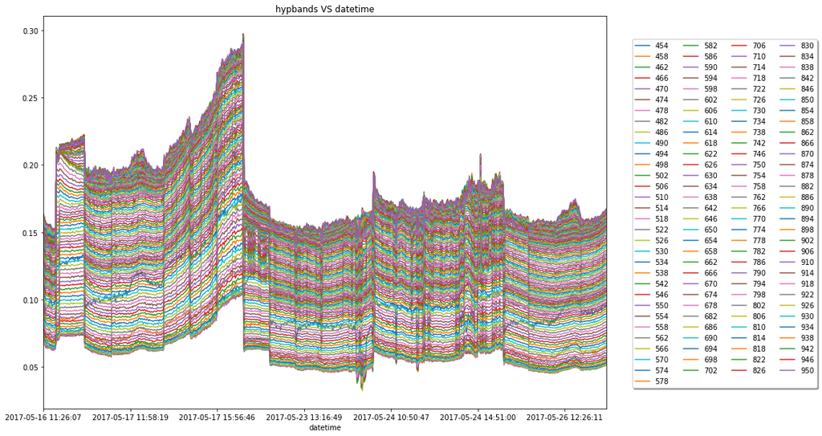

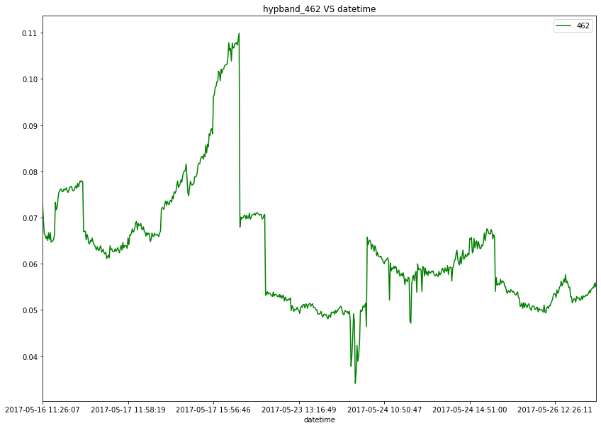

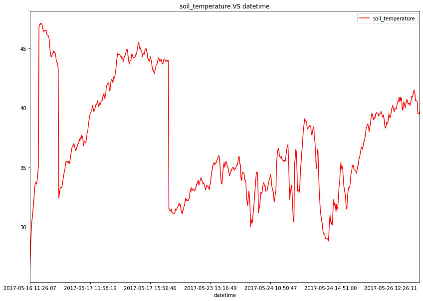

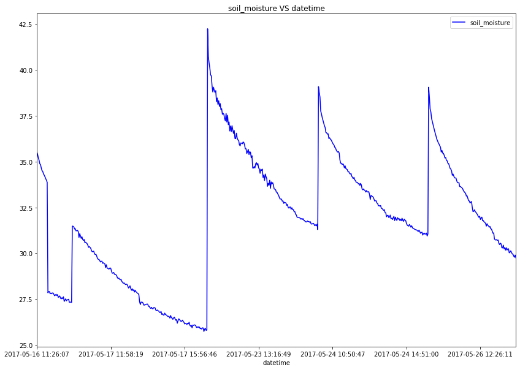

```python
import matplotlib.pyplot as plt

data1 = data_in.loc[:,hypbands]

# tracer des hypbands
ax = data1.sort_index().plot(figsize=(28,10))
chartBox = ax.get_position()
ax.set_position([chartBox.x0, chartBox.y0, chartBox.width*0.5, chartBox.height])
ax.legend(hypbands,
          loc='upper right', bbox_to_anchor=(1.38, 0.95), shadow=True, ncol=4)
ax.set_title('hypbands VS datetime' )
plt.show()

#Tracer des hypbands 462
data_in.loc[:,['462']].sort_index().plot(figsize=(14,10),color='g')
plt.title('hypband_462 VS datetime' )
plt.show()

#Tracer de la température du sol (soil_temperature)
data_in.loc[:,['soil_temperature']].sort_index().plot(figsize=(14,10),color='r')
plt.title('soil_temperature VS datetime' )
plt.show()

#Tracer de l'humidité du sol(soil_moisture)
data_in.loc[:,['soil_moisture']].sort_index().plot(figsize=(14,10),color='b')
plt.title('soil_moisture VS datetime' )
plt.show()
```

**Nous remarquons nos données hypbands ont le même comportement aussi la température à un comportement contraire à celui de l'humidité du sol se la voudra dire quand la température du sol augmente (ou diminue), l'humidité du sol diminue (ou augmente) les hypbands on le même comportement face à l'humidité du sol**

## **Analyse de correlation**

utilisons une paire de graphe pour voir comment la variable indépendante se comporte entre elles

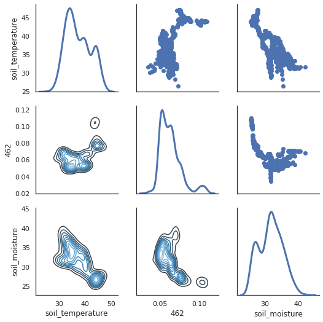

```python
import seaborn as sns
sns.set(style="white")
df = data_in.loc[:,['soil_temperature','462','soil_moisture']]
g = sns.PairGrid(df, diag_sharey=False)
g.map_lower(sns.kdeplot, cmap="Blues_d")
g.map_upper(plt.scatter)
g.map_diag(sns.kdeplot, lw=3)
```

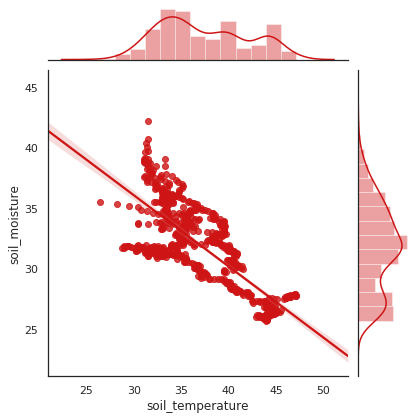

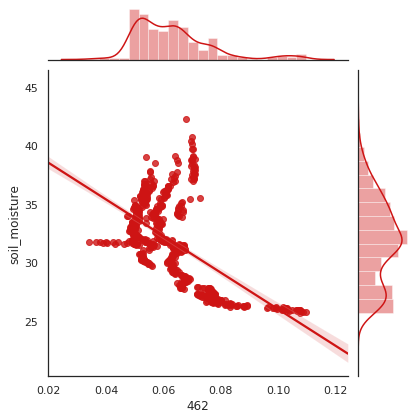

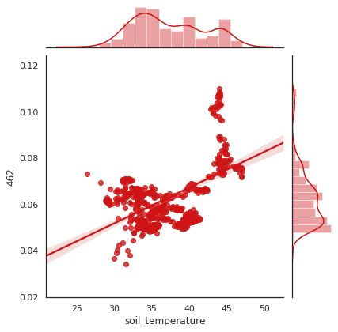

```python
sns.jointplot(data_in.loc[:,'soil_temperature'], data_in.loc[:,'soil_moisture'], kind="regg", color="#ce1414")
sns.jointplot(data_in.loc[:,'462'], data_in.loc[:,'soil_moisture'], kind="regg", color="#ce1414")
sns.jointplot(data_in.loc[:,'soil_temperature'], data_in.loc[:,'462'], kind="regg", color="#ce1414")
```

nous constatons que toutes nos variables sont corrélées entre elles. il va falloir choisir entre les données hypbands et la température pour expliquer l'humidité du sollmais d'abord voyons les coefficients de corrélation de l'ensemble de données

```python
#corrélation
data_in.corr()
```

|  | soil_moisture | soil_temperature | 454 | 458 | 462 | 466 | 470 | 474 | 478 | 482 | 486 | 490 | 494 | 498 | 502 | 506 | 510 | 514 | 518 | 522 | 526 | 530 | 534 | 538 | 542 | 546 | 550 | 554 | 558 | … |
| --- | --- | --- | --- | --- | --- | --- | --- | --- | --- | --- | --- | --- | --- | --- | --- | --- | --- | --- | --- | --- | --- | --- | --- | --- | --- | --- | --- | --- | --- | --- |
| soil_moisture | 1.000000 | -0.783793 | -0.632859 | -0.600898 | -0.593471 | -0.606489 | -0.604637 | -0.609281 | -0.612298 | -0.609630 | -0.609328 | -0.614105 | -0.611694 | -0.615963 | -0.623830 | -0.629397 | -0.637448 | -0.646767 | -0.651286 | -0.655110 | -0.659032 | -0.665640 | -0.671056 | -0.671956 | -0.674085 | -0.676444 | -0.679180 | -0.681609 | -0.684386 | … |
| soil_temperature | -0.783793 | 1.000000 | 0.655326 | 0.580581 | 0.543776 | 0.536189 | 0.524663 | 0.523120 | 0.522408 | 0.516152 | 0.512151 | 0.513264 | 0.511785 | 0.513235 | 0.519317 | 0.523608 | 0.531756 | 0.539745 | 0.542438 | 0.547580 | 0.549453 | 0.554843 | 0.559648 | 0.561763 | 0.564767 | 0.565311 | 0.567082 | 0.570985 | 0.573807 | … |
| 454 | -0.632859 | 0.655326 | 1.000000 | 0.980909 | 0.962422 | 0.948867 | 0.939276 | 0.932906 | 0.928499 | 0.922335 | 0.919924 | 0.917505 | 0.913850 | 0.911318 | 0.910862 | 0.909932 | 0.910017 | 0.910837 | 0.909050 | 0.909761 | 0.908349 | 0.907298 | 0.907922 | 0.907884 | 0.908547 | 0.906962 | 0.905512 | 0.906827 | 0.907626 | … |
| 458 | -0.600898 | 0.580581 | 0.980909 | 1.000000 | 0.992846 | 0.986519 | 0.981285 | 0.977164 | 0.973876 | 0.970256 | 0.968545 | 0.966039 | 0.964057 | 0.962192 | 0.961335 | 0.960332 | 0.959509 | 0.958927 | 0.957289 | 0.957201 | 0.955885 | 0.954161 | 0.953787 | 0.953307 | 0.953347 | 0.951928 | 0.950658 | 0.951248 | 0.951350 | … |
| 462 | -0.593471 | 0.543776 | 0.962422 | 0.992846 | 1.000000 | 0.997011 | 0.994752 | 0.992151 | 0.990275 | 0.987780 | 0.986926 | 0.985355 | 0.983933 | 0.982517 | 0.981412 | 0.980778 | 0.979580 | 0.978858 | 0.977667 | 0.977250 | 0.976136 | 0.974517 | 0.973805 | 0.973476 | 0.973264 | 0.972178 | 0.970816 | 0.970887 | 0.970947 | … |
| ... | ... | ... | ... | ... | ... | ... | ... | ... | ... | ... | ... | ... | ... | ... | ... | ... | ... | ... | ... | ... | ... | ... | ... | ... | ... | ... | ... | ... | ... | … |
| 934 | -0.760315 | 0.649388 | 0.914523 | 0.933660 | 0.940143 | 0.945072 | 0.942840 | 0.943434 | 0.943461 | 0.941822 | 0.940768 | 0.944194 | 0.943399 | 0.943781 | 0.946761 | 0.949130 | 0.951338 | 0.954177 | 0.955728 | 0.957362 | 0.958004 | 0.960339 | 0.962761 | 0.963462 | 0.964503 | 0.964803 | 0.965991 | 0.966910 | 0.967830 | … |
| 938 | -0.760900 | 0.651948 | 0.916291 | 0.933641 | 0.939029 | 0.943351 | 0.940686 | 0.941157 | 0.941034 | 0.939242 | 0.938158 | 0.941620 | 0.940616 | 0.940925 | 0.943945 | 0.946309 | 0.948515 | 0.951427 | 0.952947 | 0.954618 | 0.955268 | 0.957630 | 0.960060 | 0.960735 | 0.961804 | 0.962119 | 0.963315 | 0.964245 | 0.965199 | … |
| 942 | -0.762078 | 0.655376 | 0.918359 | 0.934102 | 0.938206 | 0.942117 | 0.939049 | 0.939378 | 0.939042 | 0.937149 | 0.936096 | 0.939377 | 0.938213 | 0.938518 | 0.941607 | 0.943910 | 0.946145 | 0.949101 | 0.950615 | 0.952309 | 0.952941 | 0.955297 | 0.957703 | 0.958330 | 0.959436 | 0.959748 | 0.960924 | 0.961873 | 0.962852 | … |
| 946 | -0.763123 | 0.658623 | 0.920267 | 0.934375 | 0.936882 | 0.940237 | 0.936617 | 0.936775 | 0.936166 | 0.934160 | 0.933075 | 0.936179 | 0.934922 | 0.935164 | 0.938339 | 0.940585 | 0.942842 | 0.945833 | 0.947296 | 0.949083 | 0.949642 | 0.952030 | 0.954414 | 0.954976 | 0.956096 | 0.956399 | 0.957606 | 0.958603 | 0.959575 | … |
| 950 | -0.762900 | 0.662168 | 0.922587 | 0.934653 | 0.935478 | 0.938071 | 0.933860 | 0.933756 | 0.932835 | 0.930623 | 0.929445 | 0.932371 | 0.930944 | 0.931142 | 0.934340 | 0.936525 | 0.938826 | 0.941831 | 0.943219 | 0.945127 | 0.945547 | 0.947966 | 0.950350 | 0.950853 | 0.951964 | 0.952266 | 0.953470 | 0.954526 | 0.955510 | … |

127 rows × 127 columns

## **Détection de multicolinéarité**

```python
from statsmodels.stats.outliers_influence import variance_inflation_factor
X_selected=pd.DataFrame(data_in.loc[:,"454":])
# Pour chaque element de X_selected, calculez le facteur d'inflation de la variance(VIF) et enregistrez-le dans la DataFrame
vif = pd.DataFrame()
vif["VIF Factor"] = [variance_inflation_factor(X_selected.values, i) for i in range(X_selected.shape[1])]
vif["features"] = X_selected.columns
vif.round(1)
```

|  | VIF Factor | features |
| --- | --- | --- |
| 0 | 2271.4 | 454 |
| 1 | 7584.0 | 458 |
| 2 | 16149.3 | 462 |
| 3 | 26631.1 | 466 |
| 4 | 33154.3 | 470 |
| ... | ... | ... |
| 120 | 388696.6 | 934 |
| 121 | 322598.6 | 938 |
| 122 | 373144.7 | 942 |
| 123 | 366943.6 | 946 |
| 124 | 113050.1 | 950 |

125 rows × 2 columns

**Tout nos VIF sont supérieurs à 5 ce qui veut dire qu'il existe une forte colinéarité entre nos données hypbandsspour resourdre ce problème nous allons utiliser une régression ridge pour expliquer l'humidité avec les hypbands**

Nous souhaitons utiliser la température d'une part pour prédire l'humidité et d'autre part les hypbands. pour cela nous auront deux catégories de données **a** pour l'analyse relative à la température et **b** pour celle hypbands

```python
#Définissons nos variables
X_a= data_in.loc[:,['soil_temperature']]
y_a= data_in.loc[:,['soil_moisture']]

X_b= data_in.loc[:,"454":]
y_b= data_in.loc[:,['soil_moisture']]
```

## Division de la dataset en données d'entrainement et de test

```python
# Ensemble de données divisé
from sklearn.model_selection import train_test_split
X_train_a, X_test_a, y_train_a, y_test_a = train_test_split( X_a, y_a, test_size=0.5, random_state=42, shuffle=True)

X_train_b, X_test_b, y_train_b, y_test_b = train_test_split( X_b, y_b, test_size=0.5, random_state=42, shuffle=True)
```

## Mise à Échelle

```python
from sklearn.preprocessing import MinMaxScaler
mms = MinMaxScaler()

X_train_std_a = mms.fit_transform(X_train_a)
X_test_std_a = mms.transform(X_test_a)

X_train_std_b = mms.fit_transform(X_train_b)
X_test_std_b = mms.transform(X_test_b)
```

## Construction du modèle de régression linéaire simple avec la variable température(soil_température)

```python
from sklearn.linear_model import LinearRegression
from sklearn.metrics import r2_score
model = LinearRegression()
model.fit(X_train_std_a,y_train_a)

print("The model explains {:.2f}% of the soil_moisture.".format(model.score(X_train_std_a,y_train_a)*100))
```

```
The model explains 58.17% of the soil_moisture.
```

### **Le modèle explique 58,17% de l'humidité du sol.**

**visualisation**

Tout d'abord, nous utilisons un nuage de points pour tracer les observations réelles, avec x_train std sur l'axe des x et y_train std sur l'axe des y.Pour la droite de régression, nous utiliserons x_train std sur l'axe x puis les prédictions des observations x_train std sur l'axe y.

```python
a = model.coef_
b = model.intercept_

predictions = a @ X_train_std_a.T + b
```

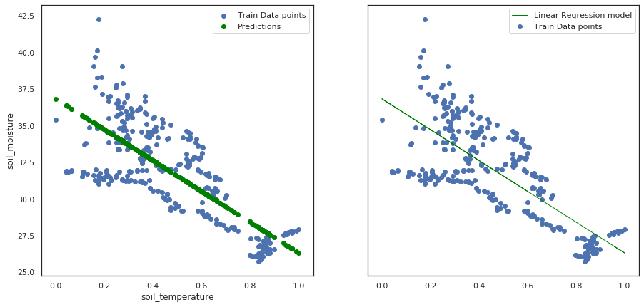

```python
fig, (ax0, ax1) = plt.subplots(1,2, figsize=(15,7), sharex=True, sharey=True)

ax0.scatter(X_train_std_a,y_train_a, label="Train Data points")
ax1.scatter(X_train_std_a,y_train_a, label="Train Data points")

ax0.scatter(X_train_std_a, predictions.reshape((324,)),
         color='green', lw=1, label="Predictions")

ax1.plot(X_train_std_a, predictions.reshape((324,)),
         color='green', lw=1, label="Linear Regression model")


# Some plotting parameters to make the plot look nicer
ax0.set_xlabel("soil_temperature")
ax0.set_ylabel("soil_moisture")
ax0.legend();
ax1.legend();
```

Nous répétons la même tâche pour notre ensemble de données de test.il est à noter que nous allons utiliser la même prediction faite avec "X_train_std'" Vous voyez, notre modèle de régresseur a été formé par l'ensemble de formation et nous en avons obtenu une équation unique, que nous allons utiliser ici aussi.

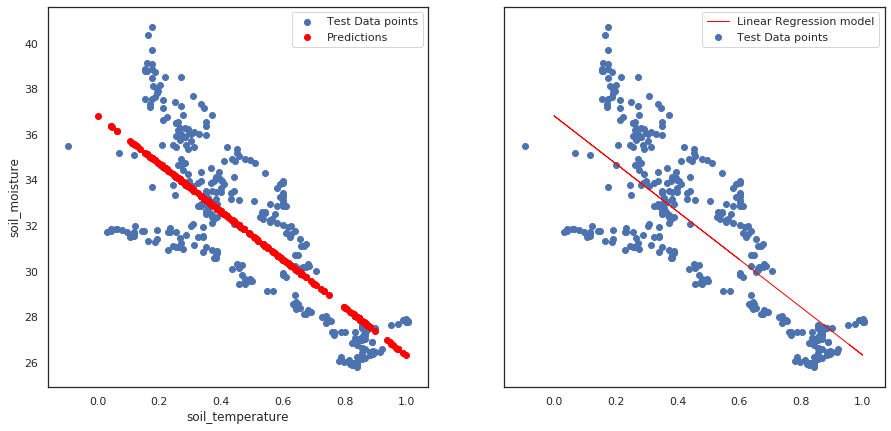

```python
fig, (ax0, ax1) = plt.subplots(1,2, figsize=(15,7), sharex=True, sharey=True)

ax0.scatter(X_test_std_a,y_test_a, label="Test Data points")
ax1.scatter(X_test_std_a,y_test_a, label="Test Data points")

ax0.scatter(X_train_std_a, predictions.reshape((324,)),
         color='red', lw=1, label="Predictions")

ax1.plot(X_train_std_a, predictions.reshape((324,)),
         color='red', lw=1, label="Linear Regression model")


# Quelques paramètres de traçage pour rendre le tracé plus agréable
ax0.set_xlabel("soil_temperature")
ax0.set_ylabel("soil_moisture")
ax0.legend();
ax1.legend();
```

## Construction d'un modèle de régression polynomiale avec la variable température(soil température) pour voir si notre score s'améliore

```python
from sklearn.preprocessing import PolynomialFeatures
features = PolynomialFeatures(degree=2)
X_poly_train = features.fit_transform(X_train_std_a)
```

```python
X_poly_train.shape
```

```
(324, 3)
```

```python
from sklearn.linear_model import LinearRegression
from sklearn.metrics import r2_score
full_polynomial_model = LinearRegression()
full_polynomial_model.fit(X_poly_train,y_train_a)

print("The model explains {:.2f}% of the soil_moisture.".format(full_polynomial_model.score(X_poly_train,y_train_a)*100))
```

```
The model explains 62.45% of the soil_moisture.
```

### **Le modèle explique 62,45% de l'humidité du sol.**

**Visualisation**

```python
a = full_polynomial_model.coef_
b = full_polynomial_model.intercept_

predictions = a @ X_poly_train.T + b
```

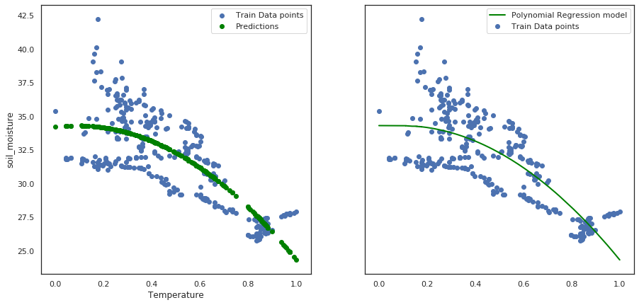

```python
fig, (ax0, ax1) = plt.subplots(1,2, figsize=(15,7), sharex=True, sharey=True)

ax0.scatter(X_train_std_a,y_train_a, label="Train Data points")
ax1.scatter(X_train_std_a,y_train_a, label="Train Data points")

ax0.scatter(X_train_std_a, predictions.reshape((324,)),
         color='green', lw=1, label="Predictions")

ax1.plot(sorted(X_train_std_a), sorted(predictions.reshape((324,)), reverse=True),
         color='green', lw=2, label="Polynomial Regression model")


# Quelques paramètres de traçage pour rendre le tracé plus agréable
ax0.set_xlabel("Temperature")
ax0.set_ylabel("soil_moisture")
ax0.legend();
ax1.legend();
```

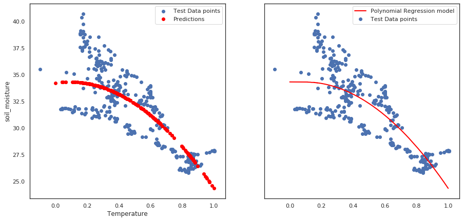

```python
fig, (ax0, ax1) = plt.subplots(1,2, figsize=(15,7), sharex=True, sharey=True)

ax0.scatter(X_test_std_a,y_test_a, label="Test Data points")
ax1.scatter(X_test_std_a,y_test_a, label="Test Data points")

ax0.scatter(X_train_std_a, predictions.reshape((324,)),
         color='red', lw=1, label="Predictions")

ax1.plot(sorted(X_train_std_a), sorted(predictions.reshape((324,)), reverse=True),
         color='red', lw=2, label="Polynomial Regression model")


# Some plotting parameters to make the plot look nicer
ax0.set_xlabel("Temperature")
ax0.set_ylabel("soil_moisture")
ax0.legend();
ax1.legend();
```

## Construction du modèle de régression Ridge polynomiale avec les hypbands

Comme nous l'avons mentionné plus haut compte tenue du poids des variables hypbands et de la collinéarité observée nous utilisons la regression ridge

```python
features = PolynomialFeatures(degree=2)
X_poly_train_b = features.fit_transform(X_train_std_b)
```

```python
#Recherche de parametre alpha

from sklearn.linear_model import RidgeCV
regr_cv = RidgeCV(alphas=10**np.linspace(10,-2,100)*0.5)

# Entrainnement du modèle régression Ridge
model_cv = regr_cv.fit(X_poly_train_b, y_train_b)
# alpha
model_cv.alpha_
```

```
0.005
```

```python
from sklearn.linear_model import Ridge
lr1= Ridge(alpha=0.005)
lr1.fit(X_poly_train_b, y_train_b)
print("The model explains {:.2f}% of the soil_moisture.".format(lr1.score(X_poly_train_b, y_train_b)*100))
```

```
The model explains 97.33% of the soil_moisture.
```

### **Le modèle explique 97,33% de l'humidité du sol.**

```python
X_train_std_b.shape, y_train_b.shape
```

```
((324, 125), (324, 1))
```

pour visualiser nos données nous allons procéder à une réduction de dimension carX_train_std_b, y_train_b doivent avoir la même taille

```python
from sklearn.decomposition import PCA
# definir le nombre de composants principaux des données
pca = PCA(n_components=1)
# Entrainnement du modèle PCA
X_train_pca= pca.fit_transform(X_train_std_b)
X_test_pca= pca.transform(X_test_std_b)

print("Original shape: {}".format(str(X_train_std_b.shape)))
print("Reduced shape: {}".format(str(X_train_pca.shape)))
print("Original shape: {}".format(str(X_test_std_b.shape)))
print("Reduced shape: {}".format(str(X_test_pca.shape)))
```

```
Original shape: (324, 125)
Reduced shape: (324, 1)
Original shape: (325, 125)
Reduced shape: (325, 1)
```

**visualisation**

```python
a = lr1.coef_
b = lr1.intercept_

predictions = a @ X_poly_train_b.T + b
```

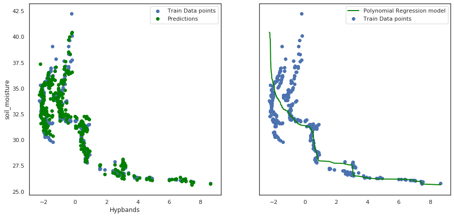

```python
fig, (ax0, ax1) = plt.subplots(1,2, figsize=(15,7), sharex=True, sharey=True)

ax0.scatter(X_train_pca,y_train_b, label="Train Data points")
ax1.scatter(X_train_pca,y_train_b, label="Train Data points")

ax0.scatter(X_train_pca, predictions.reshape((324,)),
         color='green', lw=1, label="Predictions")

ax1.plot(sorted(X_train_pca), sorted(predictions.reshape((324,)), reverse=True),
         color='green', lw=2, label="Polynomial Regression model")


# Quelques paramètres de traçage pour rendre le tracé plus agréable
ax0.set_xlabel("Hypbands")
ax0.set_ylabel("soil_moisture")
ax0.legend();
ax1.legend();
```

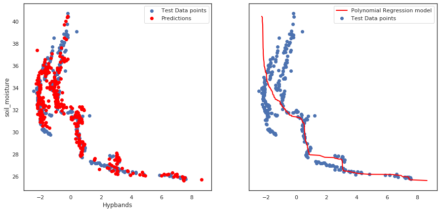

```python
fig, (ax0, ax1) = plt.subplots(1,2, figsize=(15,7), sharex=True, sharey=True)

ax0.scatter(X_test_pca,y_test_b, label="Test Data points")
ax1.scatter(X_test_pca,y_test_b, label="Test Data points")

ax0.scatter(X_train_pca, predictions.reshape((324,)),
         color='red', lw=1, label="Predictions")

ax1.plot(sorted(X_train_pca), sorted(predictions.reshape((324,)), reverse=True),
         color='red', lw=2, label="Polynomial Regression model")


# Quelques paramètres de traçage pour rendre le tracé plus agréable
ax0.set_xlabel("Hypbands")
ax0.set_ylabel("soil_moisture")
ax0.legend();
ax1.legend();
```

# Formation d'un pepeline et sélection du meilleur modèle

### Linear Polynomial Regression

```python
from sklearn.pipeline import Pipeline
from sklearn.preprocessing import MinMaxScaler
from sklearn.preprocessing import PolynomialFeatures
from sklearn.linear_model import LinearRegression
from sklearn.metrics import mean_squared_error

pipe_lr0 = Pipeline([('scl', MinMaxScaler()),
                    ('features', PolynomialFeatures(degree=2)),
                    ('reg', LinearRegression())])

pipe_lr0.fit(X_train_a, y_train_a)
print('Train Accuracy: %.3f' % pipe_lr0.score( X_train_a, y_train_a))
print('Test Accuracy: %.3f' % pipe_lr0.score( X_test_a, y_test_a))
y_pred = pipe_lr0.predict(X_test_a)
print('mean_squared_error: %.3f' % mean_squared_error(y_test_a, y_pred))
```

```
Train Accuracy: 0.624
Test Accuracy: 0.652
mean_squared_error: 4.533
```

## Ridge

```python
from sklearn.linear_model import Ridge
pipe_lr1 = Pipeline([('scl', MinMaxScaler()),
                    ('features', PolynomialFeatures(degree=2)),
                    ('reg', Ridge(alpha=0.005))])

pipe_lr1.fit(X_train_b, y_train_b)
print('Train Accuracy: %.3f' % pipe_lr1.score( X_train_b, y_train_b))
print('Test Accuracy: %.3f' % pipe_lr1.score( X_test_b, y_test_b))
y_pred = pipe_lr1.predict(X_test_b)
print('mean_squared_error: %.3f' % mean_squared_error(y_test_b, y_pred))
```

```
Train Accuracy: 0.973
Test Accuracy: 0.883
mean_squared_error: 1.522
```

**Comme on peut le constater c'est la régression ridge qui a le meilleur score et fait le moins d'erreurs**

# Visualisons les prédictions effectuées avec les donnés tests par notre modèle

```python
#obtenir la liste d'index
data=y_test_b.copy()
data.reset_index(inplace=True)
index = data.datetime.values.tolist()
```

```python
#conversion tableau numpy en  DataFrame
y_pred=pd.DataFrame(y_pred)
#Concatenation sans index
y_pred.reset_index(drop=True, inplace=True)
y_test_b.reset_index(drop=True,inplace=True)
# ajout de l'index
dfc = pd.concat( [y_test_b, y_pred], axis=1)
dfc.columns = ['soil_moisture_actual', 'soil_moisture_pred']
dfc['datetime']= index
pd.to_datetime(dfc.datetime)
dfc=dfc.set_index(['datetime'])
dfc
```

| datetime | soil_moisture_actual | soil_moisture_pred |
| --- | --- | --- |
| 2017-05-26 13:44:10 | 30.17 | 30.206421 |
| 2017-05-17 15:36:12 | 26.42 | 27.761382 |
| 2017-05-26 12:14:11 | 32.23 | 31.545364 |
| 2017-05-24 15:33:00 | 31.15 | 30.838552 |
| 2017-05-23 11:04:26 | 38.47 | 38.207378 |
| ... | ... | ... |
| 2017-05-16 16:29:51 | 27.79 | 27.910564 |
| 2017-05-23 13:54:49 | 33.85 | 33.487992 |
| 2017-05-24 12:50:29 | 33.13 | 32.673270 |
| 2017-05-17 10:34:22 | 30.81 | 31.233508 |
| 2017-05-24 15:47:00 | 30.94 | 31.970163 |

325 rows × 2 columns

[figure not shown]

```python
dfc.sort_index().plot.bar(figsize=(200,6))
plt.legend(loc='upper left')
```

# Sauvegarde de notre Model en API

```python
import pickle

pickle.dump(pipe_lr1, open('model.pkl','wb'))

model = pickle.load(open('model.pkl','rb'))
```

# Prediction avec l'API

Nous allons par exemple prédire l'humidité du sol (soil_moisture) avec les données de 125 bandes spectrales allant de 450 nm à 950 nm et une résolution spectrale de 4 nm enregistré le '2017-05-24 15:47:00'

```python
X_test_b.loc[X_test_b.index.isin(['2017-05-24 15:47:00'])]
```

| datetime | 454 | 458 | 462 | 466 | 470 | 474 | 478 | 482 | 486 | 490 | 494 | 498 | 502 | 506 | 510 | 514 | 518 | 522 | 526 | 530 | 534 | 538 | 542 | 546 | 550 | 554 | 558 | 562 | 566 | … |
| --- | --- | --- | --- | --- | --- | --- | --- | --- | --- | --- | --- | --- | --- | --- | --- | --- | --- | --- | --- | --- | --- | --- | --- | --- | --- | --- | --- | --- | --- | --- |
| 2017-05-24 15:47:00 | 0.106082 | 0.073468 | 0.066296 | 0.064176 | 0.064071 | 0.063993 | 0.063672 | 0.063546 | 0.064766 | 0.066092 | 0.067057 | 0.068024 | 0.070156 | 0.07233 | 0.074128 | 0.075811 | 0.077987 | 0.080127 | 0.082018 | 0.083724 | 0.085884 | 0.087909 | 0.090589 | 0.093092 | 0.095278 | 0.097551 | 0.100247 | 0.102985 | 0.105277 | … |

1 rows × 125 columns

Convertissons ces données en une liste pour le donné à notre modèle API pour la prediction

```python
hyp=X_test_b.loc[X_test_b.index.isin(['2017-05-24 15:47:00'])].values.tolist()
hyp
```

[output not shown]

[output cut: 70 more lines]

[output not shown]

```python
print(model.predict(hyp))
```

```
[[31.97016284]]
```

### **Comme on peut le constaté notre API Model predit que l'humidité du sol sera d'environs 32%**